# Assignment_9_rmarkdown

Blake Yost

# Data Summary

A small glimpse of the data:

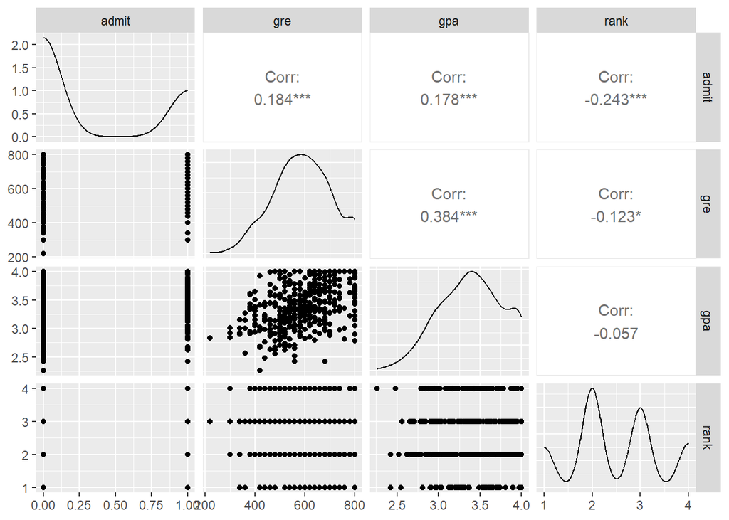

Here is a sample plot of what the data looks like

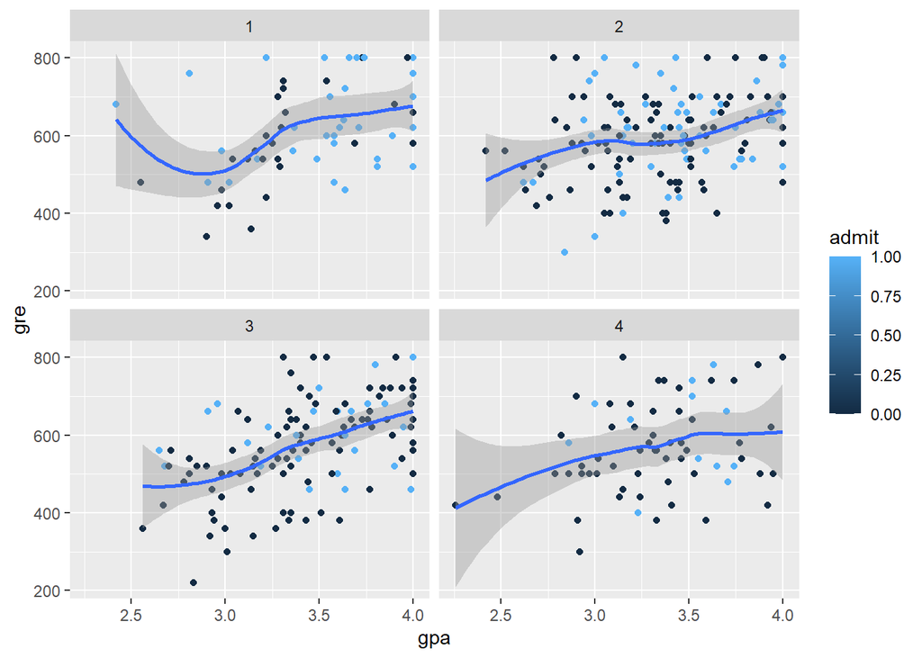

```r
df %>%
  ggplot(aes(x=gpa, y=gre, color = admit))+
  geom_point()+
  geom_smooth()+
  facet_wrap(~rank)
```

# Modeling

First we look at the effect of gpa on admittance, and then add more predictors

```r
m1 <- glm(data=df,
            formula = admit ~ gpa, family = "binomial")

m2 <- glm(data=df,
          formula = admit ~ gpa + gre, family = "binomial")

m3 <- glm(data=df,
          formula = admit ~ gpa+gre+rank, family = "binomial")

m4 <- glm(data=df,
          formula = admit ~ gpa*gre*rank, family = "binomial")
```

Here is a plot comparing the performance of each model.

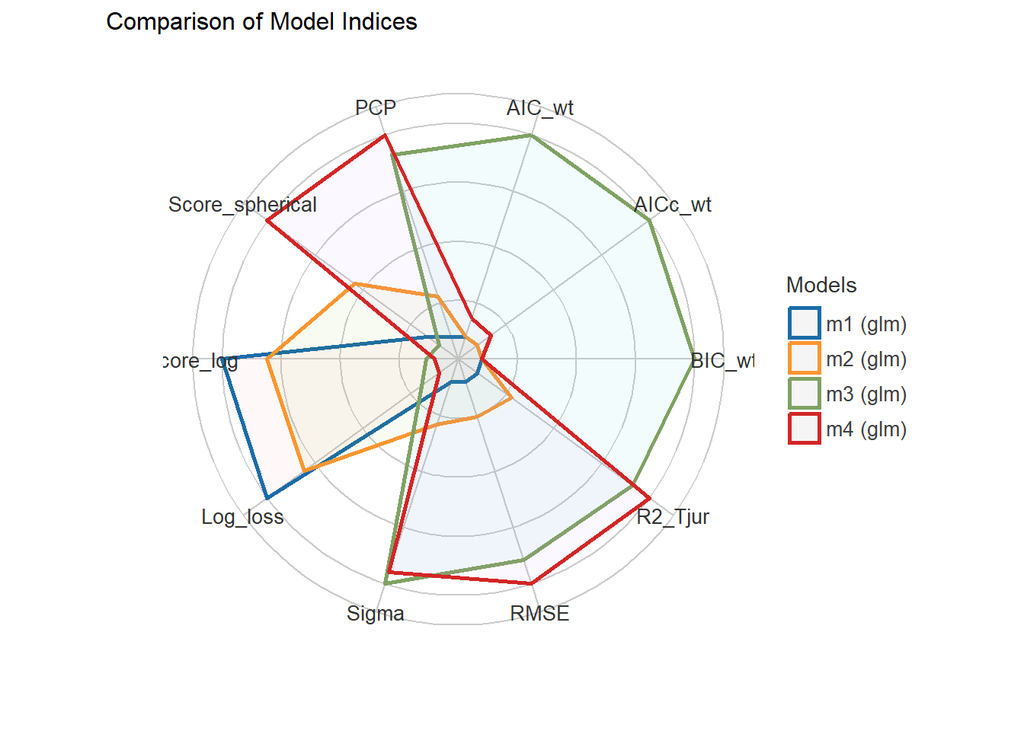

# Predictions Using m4

Let’s use model 4 to try and see some predictions based on what we found. Here we get to see the chance someone will get in based on our predictors.

```
## # A tibble: 6 x 5
##   admit   gre   gpa  rank   pred
##   <dbl> <dbl> <dbl> <dbl>  <dbl>
## 1     0   380  3.61     3 0.225
## 2     1   660  3.67     3 0.311
## 3     1   800  4        1 0.618
## 4     1   640  3.19     4 0.177
## 5     0   520  2.93     4 0.0975
## 6     1   760  3        2 0.460
```

In this new column, if the chance was greater than 0.5, we said they were admitted. If the chance was less than 0.5, they were not admitted.

```
## # A tibble: 6 x 6
##   admit   gre   gpa  rank   pred pred_v2
##   <dbl> <dbl> <dbl> <dbl>  <dbl>   <dbl>
## 1     0   380  3.61     3 0.225        0
## 2     1   660  3.67     3 0.311        0
## 3     1   800  4        1 0.618        1
## 4     1   640  3.19     4 0.177        0
## 5     0   520  2.93     4 0.0975       0
## 6     1   760  3        2 0.460        0
```